# Exercises on matrix operations in TensorFlow 1.4

Practice makes perfect

```python
import pandas as pd
import tensorflow as tf
import matplotlib.pyplot as plt
```

$\begin{bmatrix} a & b \\ c & d \end{bmatrix}$

$\begin{bmatrix} 1 & 2 \\ 3 & 4 \\ 5 & 6 \end{bmatrix}$

```python
vector1 = tf.constant ([1,3,5], tf.int16)
print(vector1)
```

```
Tensor("Const:0", shape=(3,), dtype=int16)
```

### Exercise 2. Please define a tensor: constant = matrix [1, 2, 3, 4] in format int16

$\begin{bmatrix} 1 & 2 \\ 3 & 4 \end{bmatrix}$

```python
matrix1 = tf.constant ([[1, 2],[3, 4]], tf.int16)
print (matrix1)
```

```
Tensor("Const_1:0", shape=(2, 2), dtype=int16)
```

### Exercise 3. Please define a tensor: constant = matrix [1, 2, 3, 4, 5, 6] in format int16

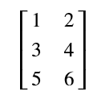

$\begin{bmatrix} 1 & 2 \\ 3 & 4 \\ 5 & 6 \end{bmatrix}$

```python
matrix2 = tf.constant ([[[1, 2],  [3, 4], [5, 6]]], tf.int16)
print (matrix2)
```

```
Tensor("Const_2:0", shape=(1, 3, 2), dtype=int16)
```

```python
matrix2.shape
```

```
TensorShape([Dimension(1), Dimension(3), Dimension(2)])
```

### Exercise 4. Create a tensor in the form of a vector of a specific shape 5, filled with zeros

$\begin{bmatrix} 0 \\ 0 \\ 0 \\ 0 \\ 0 \end{bmatrix}$

```python
kot = tf.zeros(5)
print(kot)
kot.shape
```

```
Tensor("zeros:0", shape=(5,), dtype=float32)
```

```
TensorShape([Dimension(5)])
```

### Exercise 5. Create a tensor in the form of a matrix with a specific 4x4 shape, filled with only ones

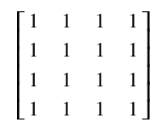

$\begin{bmatrix} 1 & 1 & 1 & 1\\ 1 & 1 & 1 & 1\\ 1 & 1 & 1 & 1\\ 1 & 1 & 1 & 1 \end{bmatrix}$

```python
fok = tf.ones ([4, 4])
print(fok)
fok.shape
```

```
Tensor("ones:0", shape=(4, 4), dtype=float32)
```

```
TensorShape([Dimension(4), Dimension(4)])
```

### Exercise 6. Matrix adding

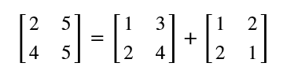

$ \begin{eqnarray} \nonumber \begin{bmatrix} 2 & 5\\ 4 & 5\\ \end{bmatrix} &=& \begin{bmatrix} 1 & 3\\ 2 & 4\\ \end{bmatrix}+ \begin{bmatrix} 1 & 2\\ 2 & 1\\ \end{bmatrix} \end{eqnarray} $

To add two matrices, their dimensions must be equal. That is, the number of rows and the number of columns of the first and second matrices must be equal.

```python
matrix3 = tf.constant ([[[1, 3], [2, 4]]], tf.int16)
matrix4 = tf.constant ([[[1, 2], [2, 1]]], tf.int16)
```

```python
PZU = tf.add(matrix3, matrix4)
```

```python
sess = tf.Session()
print(sess.run(PZU))
```

```
[[[2 5]
  [4 5]]]
```

### Exercise 7. Matrix subtraction

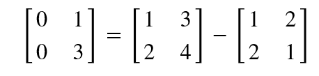

To subtract two matrices their dimensions must be equal. That is, the number of rows and the number of columns of the first and second matrices must be equal.

```python
PZU = tf.subtract(matrix3, matrix4)
```

```python
sess = tf.Session()
print(sess.run(PZU))
```

```
[[[0 1]
  [0 3]]]
```

### Exercise 8. Multiply the matrix by a number

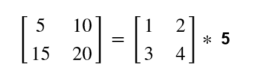

```python
matrix1 = tf.constant ([[1, 2],[3, 4]], tf.int16)
```

```python
FOK = tf.multiply (matrix1, 5)
```

```python
sess = tf.Session()
print(sess.run(FOK))
```

```
[[ 5 10]
 [15 20]]
```

### Exercise 9. Multiply the matrix by a number TensorFlow

[figure not shown]

```python
matrix5 = tf.constant ([[2,7,4],[5,2,1],[6,3,4]], tf.int16)
```

```python
ZHP = tf.multiply (matrix1, 5)
```

```python
sess = tf.Session()
print(sess.run(ZHP))
```

```
[[ 5 10]
 [15 20]]
```

### Exercise 10. Multiply the matrix by a matrix TensorFlow

Matrix multiplication is not alternating.

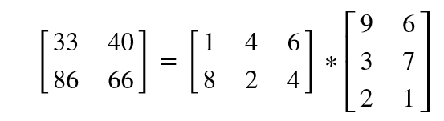

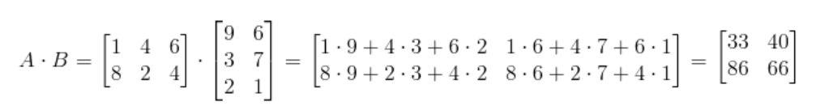

```python
matrix6 = tf.constant([[1,4,6],[8,2,4]],tf.int32)
matrix7 = tf.constant([[9,6],[3,7],[2,1]],tf.int32)

KPU = tf.matmul(matrix6,matrix7)
```

```python
sess = tf.Session()
print(sess.run(KPU))
```

```
[[33 40]
 [86 66]]
```

### Exercise 11. Multiply the matrix by a matrix TensorFlow

Matrix multiplication is not alternating.

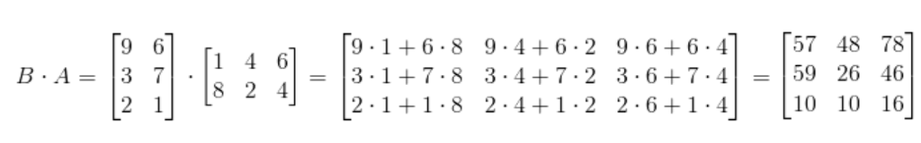

```python
KPU = tf.matmul(matrix7,matrix6)
```

```python
sess = tf.Session()
print(sess.run(KPU))
```

```
[[57 48 78]
 [59 26 46]
 [10 10 16]]
```

### Exercise 11. Multiplication of C⋅D square matrices

[figure not shown]

```python
matrix8 = tf.constant([[5,6,1],[8,7,9],[1,5,2]],tf.int32)
matrix9 = tf.constant([[4,6,7],[2,5,1],[0,3,9]],tf.int32)
```

```python
PKS = tf.matmul(matrix8,matrix9)
```

```python
sess = tf.Session()
print(sess.run(PKS))
```

```
[[ 32  63  50]
 [ 46 110 144]
 [ 14  37  30]]
```

### Exercise 11.Transpose the matrix

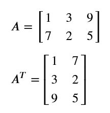

$A=\begin{bmatrix} 1 & 3 & 9 \\ 7 & 2 & 5 \\ \end{bmatrix}$

$A^T=\begin{bmatrix} 1 & 7 \\ 3 & 2 \\ 9 & 5 \\ \end{bmatrix}$

```python
x = tf.constant([[1, 3, 9], [7, 2, 5]])
GAP = tf.transpose(x)
```

```python
sess = tf.Session()
print(sess.run(GAP))
```

```
[[1 7]
 [3 2]
 [9 5]]
```

### Exercise 12. Determinant of the matrix

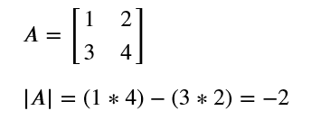

$A = \begin{bmatrix} 1 & 2 \\ 3 & 4 \end{bmatrix}$

$|A| = (1*4)-(3*2)= -2$

```python
matrix1 = tf.constant ([[1, 2],[3, 4]], tf.float32)
```

```python
PKO = tf.matrix_determinant(matrix1)
```

```python
sess = tf.Session()
print(sess.run(PKO))
```

```
-2.0
```

### Exercise 13. Diagonal matrix

Diagonal matrix - a matrix, usually square [a], whose all coefficients lying outside the main diagonal (main diagonal) are zero. In other words, it is an upper- and lower-triangular matrix at the same time.

```python
PPS = tf.diag([1.2, 1.5, 1.0, 7.1, 2, 8.3])
```

```python
sess = tf.Session()
print(sess.run(PPS))
```

```
[[1.2 0.  0.  0.  0.  0. ]
 [0.  1.5 0.  0.  0.  0. ]
 [0.  0.  1.  0.  0.  0. ]
 [0.  0.  0.  7.1 0.  0. ]
 [0.  0.  0.  0.  2.  0. ]
 [0.  0.  0.  0.  0.  8.3]]
```

### Exercise 14. Outputs random values from a truncated normal distribution

https://docs.w3cub.com/tensorflow~python/tf/truncated_normal/

The generated values follow a normal distribution with specified mean and standard deviation, except that values whose magnitude is more than 2 standard deviations from the mean are dropped and re-picked.

```python
ABC = tf.truncated_normal([2, 3])
```

```python
sess = tf.Session()
print(sess.run(ABC))
```

```
[[ 0.05371307  1.4564506  -1.7267214 ]
 [-1.7192566   1.5986782   0.91717476]]
```

```python
print(ABC.shape)
```

```
(2, 3)
```

Random values for the mean: 7 and standard deviation: 2. Generate matrix: 3 by 5, the values should be in the format: float32.

```python
KSU = tf.truncated_normal([3,5],mean=7,stddev=2.0,dtype=tf.float32)
sess = tf.Session()
```

[output not shown]

### Exercise 15. Creates a tensor filled with a scalar value.

This operation creates a tensor of shape dims and fills it with value. https://docs.w3cub.com/tensorflow~python/tf/fill/

```python
print(sess.run(tf.fill([4,2],4)))
```

```
[[4 4]
 [4 4]
 [4 4]
 [4 4]]
```

Macierz 4x2 wypełniona wartościami 4

### Exercise 16. Outputs random values from a uniform distribution.

The generated values follow a uniform distribution in the range [minval, maxval). The lower bound minval is included in the range, while the upper bound maxval is excluded.

https://docs.w3cub.com/tensorflow~python/tf/random_uniform/

```python
GAD = tf.random_uniform([3,7], minval=4, maxval=8, dtype=tf.float32)
```

```python
sess = tf.Session()
print(sess.run(GAD))
```

```
[[5.8656416 4.652042  4.3458786 5.7581544 6.0479655 6.6700726 6.035503 ]
 [5.729369  7.1762366 6.052859  6.8669724 6.278867  5.959975  7.3483486]
 [7.441143  7.3443627 6.4590683 5.6526484 5.656465  4.5448027 5.9519987]]
```

### Exercise 17. Transforming the matrix into a Tensorflow matrix

We have some kind of matrix and we want to include it in the tensorflow model.

```python
import numpy as np
KAT = np.array([[1., 2., 3.],[-3., -7., -1.],[0., 5., -2.]])
KAT
```

```
array([[ 1.,  2.,  3.],
       [-3., -7., -1.],
       [ 0.,  5., -2.]])
```

```python
DOK = tf.convert_to_tensor(KAT)
```

```python
sess = tf.Session()
print(sess.run(DOK))
```

```
[[ 1.  2.  3.]
 [-3. -7. -1.]
 [ 0.  5. -2.]]
```